# Time Series I - Data and Models

73-374 Econometrics II

## Today

- Time Series
  - Data Structure
  - Regression with time series data
  - Dependence
  - Models
- Covered in Wooldridge Ch. 10-11

## Time Series Data

- Instead of random sample from population, have many observations of same object over time
- Macroeconomic data from one country
  - GDP, Inflation, Unemployment every month/quarter/year
- Financial data
  - Price of S&P, Dow, Nasdaq every 5 minutes for 10 years
- $Y_t$, $t=1\ldots T$ ordered series of observations of variable $Y$
- If observations iid, acts just like random sample
  - Usually this is false
  - Processes evolve in way that depends on time
- Challenge for standard estimation and inference
  - Random sampling fails
- Opportunity to model structure of changes over time
  - Learn relationships
  - Use historical behavior to predict current and future behavior

## Setup

- Data consists of $T$ ordered observations of variables $Y_t$
- May have vector $(Y_t,X_t)$, $X_t$ a $k+1\times 1$ vector of predictors
- Compare to panel data: there have data ordered in time, but many observations of same process across individuals
- Now can’t use info across individuals to learn structure
- For panel data, allowed variables to be related over time
  - Saw in unobserved components model, effective sample size is not increased by adding time periods
  - Can’t say much of anything from a single series
- 1 type of model: even if data not independent, build model from variables that are independent
  - Like pooled OLS with independent errors
- Alternate possibility: “weak dependence”
  - Occurrences “far in the past” “don’t matter much today,” can treat long past history as effectively independent observations
- These are only *models* of the data
  - May be good or bad decription of series of interest

## Example: US Quarterly GDP Growth, 1947q2-2018q3 (Code)

```r
#Library to download data
library(pdfetch)
#Download Seasonally Adjusted Quarterly Real US GDP Growth
#FRED Series number "A191RL1Q225SBEA"
gdpgrowth<-pdfetch_FRED("A191RL1Q225SBEA")
#Format as Quarterly time series starting 1947q2
gdpg<-ts(gdpgrowth,start=c(1947,2),frequency=4)
plot(gdpg, main="Real US GDP Growth,
  1947q2-2018q3",xlab="Quarter",ylab="Percent Change")
```

## Example: US Quarterly GDP Growth, 1947q2-2018q3

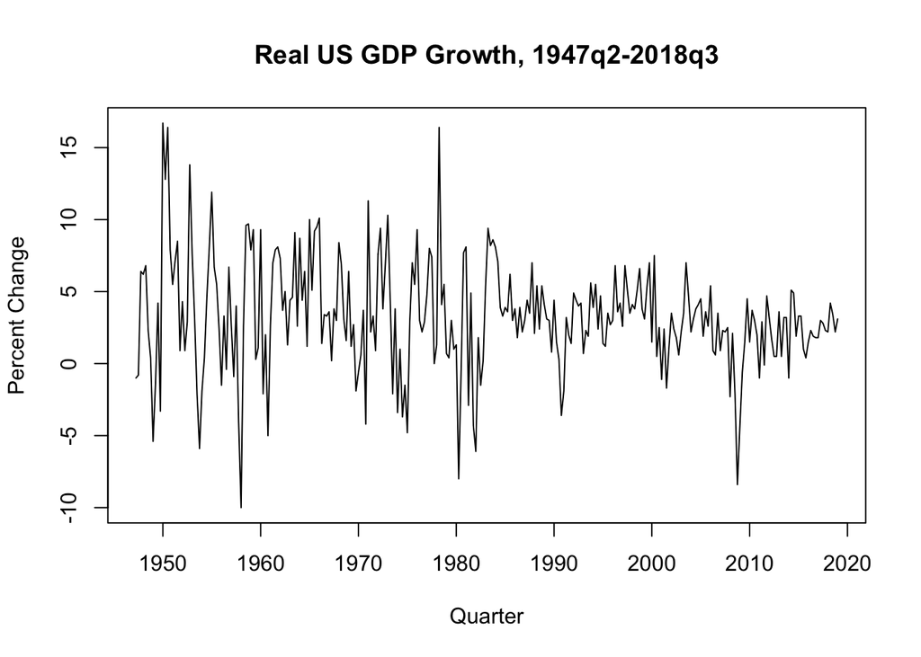

## Regression

- Relate $Y_t$ to $X_t$ based on values at same time
- E.g. $Y$ is GDP, $X$ is interest rate
  - Causal relationship called “IS curve” in macroeconomics
- Will focus discussion on linear models with time series data
  - Can do IV, nonlinear/nonparametric regression, MLE, etc
  - General principles shared
- Our usual model: $Y_t$ drawn from linear model (TS.1)
  $$Y_t=X_t^{\prime}\beta+u_t$$
- Random sampling assumption removed
- Without it, $X_s$ and $X_t$ may be correlated for $s\neq t$
- Use standard least squares regression $\widehat{\beta}=(\sum_{t=1}^{T}X_tX_t^\prime)^{-1}\sum_{t=1}^{T}X_tY_t$
- What are properties now?
- 2 approaches
  - Make very strong assumptions on $u_t$ to use finite sample theory
  - Find way to use LLN and CLT for correlated data

## Regression Assumptions

- If we can condition on entire sequence of $X_t$, and $u_t$ essentially random, don’t need to use any properties of $X$ to describe OLS
- **Strict Exogeneity** (TS.2)
  $$E[u_t|X_1\ldots X_T]=0\ \forall t$$
- With (TS.1) and (TS.3) (No multicollinearity of $X_t$, same as before), implies OLS unbiased
  $$E[\widehat{\beta}]=\beta$$
- Proof unchanged from cross-section case
- OLS is also Best (Minimum Variance) Linear Unbiased Estimator if we also have
  - (TS.4) $Var[u_t|X_1\ldots X_T]=Var(u_t)=\sigma^2$ Homoskedasticity
  - (TS.5) $E[u_s u_t]=0\ \forall s\neq t$ No serial correlation
- $\widehat{\beta}$ has a normal distribution, and usual $t$ and $F$ tests have exact $t$ and $F$ distributions if we also have
  - (TS.6) $u_t\sim i.i.d.\ N(0,\sigma^2)$ independent of all $X$

## Lags, Differences, Etc.

- Past (or sometimes future) values of variables can enter into $X_t$
- “Lag of $X_t$” takes $X_t$ 1 period back
  - Denote $X_{t-1}$ as $LX_t$, $X_{t-2}$ as $L^2 X_t$, etc
- Change or difference in $X_t$ denoted
  - $\Delta X_t:=X_t-LX_t$
- If data is column containing values, create lags by shifting index by one
- For $X_t$, $LX_t$ to be columns of same length, need to delete first observation of $X_t$: lose one data point
- Time series data format in $R$ using commands of form $gdp<-ts(gdpvector,start=1947,frequency=quarterly)$
- Can run regressions using lags, etc. using **dynlm** package
  - Syntax just like **lm**
  - Eg. `dynlm(Y~X+L(X))`

## Distributed Lags

- Regression on lags of $X$ called **distributed lag** regression
  $$Y_t=\beta_0+\beta_1x_t+\beta_2x_{t-1}+\beta_3 x_{t-2}+\ldots + u_t$$
- Include enough lags so that error term is serially uncorrelated
- Lets $x_t$ have effect on $Y_t$ today and for multiple future periods
- Effect of $x_t$ on $Y_{t+h}$ is coefficient on $x_{t-h}$
- **Impulse Response** describes effect when $x_t$ goes from zero to 1 for one period, then returns to $0$ again, as function of time $h$ from initial *shock*
- It equals $\beta_1$, $\beta_2$, $\beta_3$, $\ldots$ up to maximum included lag
- Can also describe effect of *permanent* change when $x_t$ goes from 0 to 1 then stays there as
  - $\beta_1$, $\beta_1+\beta_2$, $\beta_1+\beta_2+\beta_3$,$\ldots$
  - Sum of all coefficients is called **long run effect** of permanent change

## Dependent Data

- Regression models can describe how $Y$ changes when $X$ does, but don’t tell us how $X$ changes over time
- Most time series data exhibits serial correlation $Corr(Y_t,Y_s)\neq 0$
- Serial correlation can reflect
  - Changes in observable determinants
  - Changes in unobserved determinants
  - Or autonomous dynamics: effect of past values on future values
- Regardless of whether goal is to summarize time evolution or describe causal relationships, can be useful to model dynamics of a single series
- Many models exist, linear and nonlinear
- Will provide a few linear examples
  - Then describe properties which allow using dependent data in more general regression models

## Autoregression

- Simplest model generating correlation between $Y$ today and $Y$ in past is a (linear) autoregression (AR) model
  - $Y_t=\rho Y_{t-1}+e_t\ \forall t$
- $e_t$ uncorrelated over time and satisfies $E[e_t|Y_{t-1}]=0$
- Linear relationship between $Y$ today and $Y$ last period: regression of $Y$ on itself, hence the name
- Properties depend on value of $\rho$
  - If $|\rho|<1$ $Y_t$ is called **stable**
  - $E[Y_{t}|Y_{t-1}]=\rho Y_{t-1}$, so
  - $|E[Y_{t+1}|Y_{t}]|=|\rho Y_t|<|Y_{t}|$,
  - In fact $E[Y_{t+h}|Y_t]=E[\rho E[Y_{t+h-1}|Y_t]|Y_t]=\ldots=\rho^hY_t\rightarrow 0$ as $h\rightarrow\infty$
  - $Y$ returns to its average value over time
- If $|\rho|\geq 1$, $Y$ wanders around or even explodes
  - More on this next week
- Can extend by adding more lags of $Y$, or a constant term so mean is non-zero, or using nonlinear function
- Stability conditions correspondingly more complicated

## Moving Averages

- Can also build $Y_t$ up from unobservable components
  - **Moving Average** (MA) Model
- E.g. $Y_t=e_t+\theta e_{t-1}\ \forall t$, $e_t$ i.i.d. $(0,\sigma_e^2)$ over time
- $Cov(Y_t,Y_{t-1})=Cov(e_t+\theta e_{t-1},e_{t-1}+\theta e_{t-1})=\theta Cov(e_{t-1},e_{t-1})=\theta\sigma_e^2$
- $Cov(Y_t,Y_{t-h})=0$ for $h\geq 2$
- Can add more lags to allow dependence to last longer
- AR model has MA representation
  $$Y_t=\rho Y_{t-1}+e_t=\rho (\rho Y_{t-2}+e_{t-1})+e_t=\ldots$$
  $$=e_t+\rho e_{t-1}+ \rho^2 e_{t-2} + \rho^3 e_{t-3} + ...$$
- Can combine into **ARMA(p,q)** model
  $$Y_t = \rho_1 Y_{t-1} + \rho_2 Y_{t-2} + ... + \rho _ p Y _{t-p} +$$
  $$e_t + \theta_1 e_{t-1}+ \theta_2 e_{t-2}+\ldots+ \theta_q e_{t-q}$$
- Can describe arbitrary impulse response to unobserved components or pattern of covariances over time in this way

## Plot: AR, MA, and ARMA series (Code 1)

```r
tl<-80 #Length of simulated series
#Initialize random number generator for reproducibility
set.seed(55)
e1<-ts(rnorm(tl)) #standard normal shocks
theta<-0.7 #MA parameter
rho<-0.7 #AR parameter
yAR<-numeric(tl-1)
yMA<-numeric(tl)
yARMA<-numeric(tl)
yMA<-e1+theta*lag(e1)
for(s in 1:(tl-1)){
  #AR(1) initialized at 0
  yAR[s+1]<-rho*yAR[s]+e1[s]
  #ARMA(1,1) using same shocks
  yARMA[s+1]<-yARMA[s]+yMA[s]
}
```

## Plot: AR, MA, and ARMA series (Code 2)

```r
#Represent as same length time series
yAR<-ts(yAR[1:tl-1])
yARMA<-ts(yARMA[1:tl-1])
#Collect as Matrix
simulatedseries<-cbind(yAR,yMA,yARMA)
#Plot
ts.plot(simulatedseries,gpars=list(main=
  "AR(1),MA(1), and ARMA(1,1) Simulated data",
  ylab="Series value",lty=c(1,2,3),
  col=c("red","black","blue")))
legend("topleft",bty="n",
  expression("AR(1): rho=0.7","MA(1):
  theta=0.7","ARMA(1,1): rho=0.7, theta=0.7"),
  lty=1:3, col=c("red","black","blue"))
```

## Plot: AR, MA, and ARMA series

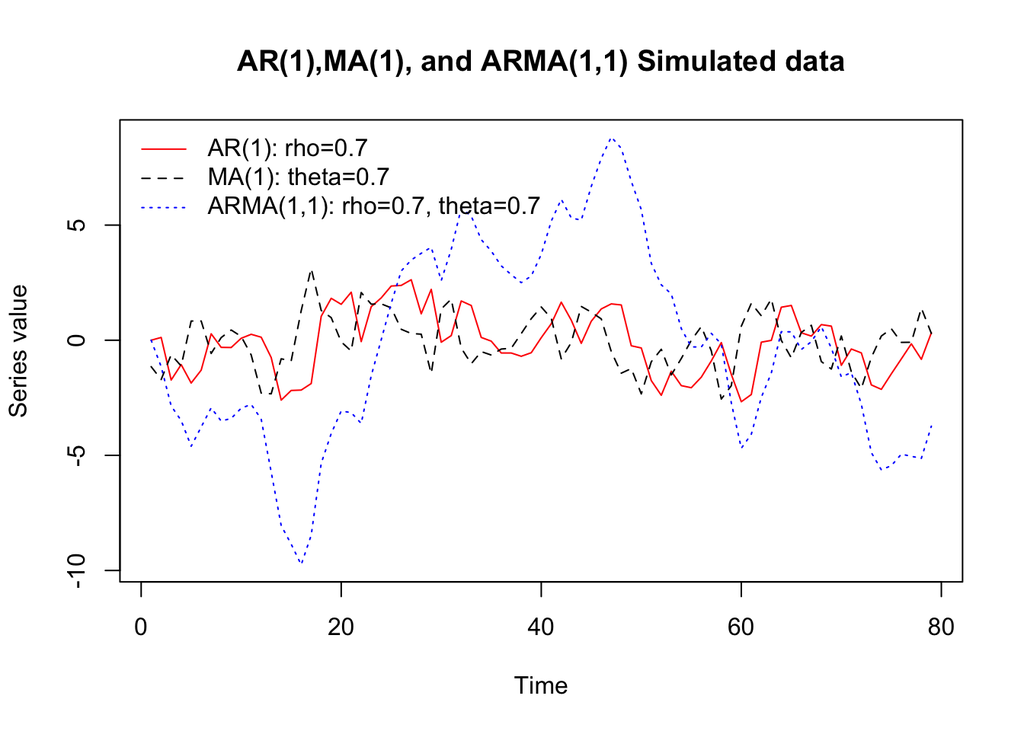

## Stationarity and Weak Dependence

- To use a time series inside our standard methods, would really like to have a law of large numbers and central limit theorem
- These hold for independent and identically distributed data
  - Each data point has same average
  - Even when some points differ from it, others likely to differ in opposite direction
  - So mean is usually close to true average
- For this to be true of a time series, need a few things
- First, it must *have* a well-defined average
  - $E[Y_t]$ and $E[Y_s]$ should be the same
- Next, correlations cannot be so large that when one point is observed large, you expect entire series to be large
- Need that future and past observations reflect similar properties
- And that the far past close enough to unrelated to the present that we can consider it separate information
- Formally guaranteed by **stationarity** and **weak dependence**

## Stationarity and Weak Dependence: Formal conditions

- (Second order) **Stationarity** means
  - $E[Y_{t}]=E[Y_{s}]$ for all $t$, $s$
  - $Cov(Y_{t},Y_{t+h})=Cov(Y_{s},Y_{s+h})$ for all $t$, $s$
- Shifting $h$ periods leaves mean and covariances unchanged
- Conditional mean can change over time, but unconditional value shouldn’t
- **Strict stationarity**
  - Entire joint distribution is unchanged by shifting time
- **Weak dependence** requires, in general
  - $Cov(Y_t,Y_{t+h})\rightarrow 0$ as $h\rightarrow \infty$
  - Also need convergence to be fast: $\sum_{h=-\infty}^{\infty}|Cov(Y_t,Y_{t+h})|<\infty$
  - Ensures that time average of $Y_t$ satisfies central limit theorem
- Stationary and weakly dependent series have similar asymptotic properties to $i.i.d.$ data when used in estimators

## Limit theorems under weak dependence

- Suppose data $y_t, t=1:T$ are stationary and weakly dependent
- Holds, e.g. for MA and stable AR and ARMA series
- **Ergodic Theorem** (generalizes law of large numbers)
  $$\frac{1}{T}\sum_{t=1}^{T}y_t\overset{p}{\rightarrow}E[y_t]$$
- Central limit theorem
  $$\frac{1}{\sqrt{T}}\sum_{t=1}^{T}(y_t-E[y_t])\overset{d}{\rightarrow}N(0,\Sigma)$$
- Where $\Sigma$ is the limit of the variance of the sum, equal to
  $$\Sigma=\sum_{h=-\infty}^{\infty}Cov(y_t,y_{t+h})=Var(Y_t)+2\sum_{h=1}^{\infty}Cov(y_t,y_{t+h})$$
- Stationarity and weak dependence ensure $\Sigma$ well-defined and finite
- $\Sigma$ called **long run variance** of series $y_t$

## Regression with dependent data

- When $X_t$ and $u_t$ satisfy weak dependence, can obtain consistency, asymptotic normality for regression
- **Strict exogeneity** $E[u_t|X_1\ldots X_T]=0\ \forall t$ can be weakened to
- **contemporaneous exogeneity** $E[u_t|X_t]=0 \forall t$
- Or as far as $Cov(X_t,u_t)=0$
- This permits $X_t$ to be related to $u_{t-1}$, for example
- Allows case where $X_t=Y_{t-1}$
  - *Autoregression* can be estimated by linear regression
- Unbiasedness fails: usually substantial bias in finite samples
- If $u_t$ homoskedastic and has no serial correlation, asymptotic variance has standard formula
- This can be true if $X_t$ contains all historical information relevant to predicting $Y_t$, possibly including lags of $Y_t$ and $X_t$
- Otherwise, limit depends on long run variance
  - Will discuss robust estimates next class

## Time Series Regression: Assumptions

- (TS.1’) Linear Model $(X_t,y_t)$ drawn from model $Y_t=X_t^{\prime}\beta+u_t$ and satisfy stationarity and weak dependence
- (TS.2’) No perfect multicollinearity of $X_t$
- (TS.3’) Contemporaneous exogeneity $E[u_t|X_t]=0 \forall t$
- or (TS 3’’) $Cov(X_t,u_t)=0$
- (TS.4’) Contemporaneous homoskedasticity: $Var(u_t|X_t)=\sigma^2$ $\forall\ t$
- (TS.5’) No serial correlation $E[u_tu_s|X_t,X_s]=0$ $\forall\ t\neq s$

## Time Series Regression: Results

- Under (TS.1’),(TS.2’),(TS.3’‘) (or (TS.3’), which implies (TS.3’’)), have consistency:
  $$\widehat{\beta}\overset{p}{\rightarrow}\beta$$
- Proof is same as before
  - But by ergodic theorem instead of law of large numbers
- Under (TS.1’)-(TS.5’) have asymptotic normality with usual variance formula
  $$\sqrt{T}(\widehat{\beta}-\beta)\overset{d}{\rightarrow}N(0,\sigma^2(E[X_tX_t^\prime])^{-1})$$
- Inference is exactly standard: t-statistics, Wald tests, CIs, etc
- Proof similar to before, using exogeneity and 0 serial correlation, plus time series CLT
- With heteroskedasticity
  - Consistent but need robust standard errors
- With serial correlation, need *another* kind of robust SEs

## Example: Monetary Policy Reaction Function (“Taylor Rule”) (Code 1)

```r
#Download quarterly series from FRED
gdppot<-pdfetch_FRED("GDPPOT") # Potential GDP
fefr<-read.csv("Data/FEDFUNDS.csv") # Downloaded quarterly
  #fed funds rate to file in directory
  # need this file to compile
ffr<-ts(fefr[,2],start=c(1954,3),frequency=4)
Lffr<-lag(ffr)
gdpdef<-pdfetch_FRED("GDPDEF") # GDP Price Deflator
gdpc1<-pdfetch_FRED("GDPC1") # Real GDP
```

## Example: Monetary Policy Reaction Function (“Taylor Rule”) (Code 2)

```r
gap<-ts(100*(gdpc1-gdppot)/gdppot,start=c(1949,2),
    frequency=4) #Output Gap
inf<-ts(100*(gdpdef-lag(gdpdef,4))/lag(gdpdef,4),
    start=c(1947,2),frequency=4) #Inflation
    # Change from 1 year ago
#Library for time series regression
library(dynlm)
taylorrule<-dynlm(ffr~L(ffr)+inf+gap)
```

## Example: Monetary Policy Reaction Function (“Taylor Rule”)

- Fed sets monetary policy by changing Fed Funds Rate $r_t$
- Want to know how Fed responds to macroeconomic variables
- Suggested that good description is that Fed responds to inflation $inf_t$ and output gap (measure of difference in GDP from “potential” level) $gap_t$
- $r_t$ evolves more slowly than inflation or output, so current value also predictable from past: $r_{t-1}$
- Regression equation for reaction function is
  $$r_t=\beta_0+\beta_1 r_{t-1} + \beta_2 inf_t + \beta_3 gap_t + u_t$$
- Run regression using data from **FRED**
  - Macroeconomic database for US

```r
taylorrule<-dynlm(ffr~L(ffr)+inf+gap)
```

## Estimates (Code)

```r
#Display results in table
library(stargazer)
stargazer(taylorrule,header=FALSE,
  omit.stat=c("ser","adj.rsq"),type="html",
  title="Fed Funds Rate Policy Rule")
```

## Estimates

**Fed Funds Rate Policy Rule**

|  | *Dependent variable:* |
| --- | --- |
|  | ffr |
| L(ffr) | 0.926*** |
|  | (0.023) |
| inf | 0.080** |
|  | (0.036) |
| gap | 0.096*** |
|  | (0.023) |
| Constant | 0.172* |
|  | (0.100) |
| Observations | 248 |
| R<sup>2</sup> | 0.945 |
| F Statistic | 1,401.172*** (df = 3; 244) |
| *Note:* | p<0.1; p<0.05; p<0.01 |

## Conclusion

- Time series present another design for data
- Serial correlation makes usual inference difficult
- But can *model* serial correlation to describe properties of data
- With strong exogeneity, can do regressions using time series data and rely on finite sample properties
- If time series are weak dependent, have modified LLN and CLT
- Can do regression and get consistency and asymptotics
- Same results extend to most other estimators we’ve seen in class

## Next Time

- More time series
  - Trends, seasonality, integration, failure of weak dependence
  - Serial Correlation
  - Inference